# Data Translation Project

Veng Leap Chan

2022-05-22

Reading In the Data

```r
# dv
load('king_dailyvisits_load.Rdata')

#ov
load('king_originvisits_load.Rdata')

#neighborhood_names (only Seattle)
load('neighborhood_names.Rdata')
```

King_Dailyvisits_load (dv)

```r
vtable(dv,lush=TRUE)
```

dv

| Name | Class | Values | Missing | Summary |
| --- | --- | --- | --- | --- |
| date | Date | Time: 2020-07-01 to 2020-07-31 | 0 | mean: 18459, sd: 8.944, nuniq: 31 |
| naics_code | integer | Num: 3231 to 928120 | 0 | mean: 553629.204, sd: 143328.536, nuniq: 282 |
| naics_title | character | ‘Aircraft Manufacturing’ ‘All Other Amusement and Recreation Industries’ ‘All Other Automotive Repair and Maintenance’ ‘All Other Business Support Services’ ‘All Other Consumer Goods Rental’ and more | 186 | nuniq: 276 |
| brands | character | ’’ ‘24 Hour Fitness’ ‘7-Eleven’ ‘76’ ‘85 Degrees C Bakery Cafe’ and more | 0 | nuniq: 958 |
| visits_by_day | integer | Num: 0 to 15129 | 0 | mean: 102.512, sd: 627.172, nuniq: 1349 |

Looking at this data, there are 5 variables, date, naics_code, niacs_title, brands, and vists_by_day. Looking at the vtables and the documentation, we see that niacs_title is missing some values.

```r
naics_title_missing = dv %>%
  filter(is.na(naics_title))
```

Through further investigation, I see that the missing naics title all have missing brands, which could mean that the these data points are of niche, smaller brands in niche industries. Since we still have naics code, this will not interfere what we see.

This data set tell us about the number of visits made to a certain store, naics code on a specific date in king county.

```r
industry = ov %>%
  mutate(naics_two_digit = ifelse(nchar(naics_code)==4,floor(naics_code/100),floor(naics_code/10000)))%>%
  group_by(naics_two_digit) %>%
  summarize(count = n()) %>%
  arrange(-count)
```

```r
vtable(ov,lush=TRUE)
```

ov

| Name | Class | Values | Missing | Summary |
| --- | --- | --- | --- | --- |
| naics_code | integer | Num: 3231 to 928120 | 0 | mean: 565494.32, sd: 144905.437, nuniq: 282 |
| naics_title | character | ‘Aircraft Manufacturing’ ‘All Other Amusement and Recreation Industries’ ‘All Other Automotive Repair and Maintenance’ ‘All Other Business Support Services’ ‘All Other Consumer Goods Rental’ and more | 2064 | nuniq: 276 |
| brands | character | ’’ ‘24 Hour Fitness’ ‘7-Eleven’ ‘76’ ‘85 Degrees C Bakery Cafe’ and more | 0 | nuniq: 958 |
| GEOID | character | ‘010010201001’ ‘010010205002’ ‘010010209002’ ‘010030103002’ ‘010030103003’ and more | 179 | nuniq: 15856 |
| visits | numeric | Num: 4 to 1072 | 179 | mean: 8.45, sd: 17.964, nuniq: 360 |

This data set is an aggregate data set and does not provide specific times and dates, but a total of all the visits in the month of July. Instead, it provides a census block of the where the customers are from to visit the store, which can be extremely useful.

My goal from briefly looking at the data is to first find a specific industry to take a closer look into, choose a company to observe and try to improve upon their business.

## Chart 1 - Naics Titles with the most Brands

As there are missing brands due to its size, I wanted to combine the Naics titles and see which among them has the most brands. I filtered the ov data to remove data points without any brand names as I do not believe it could be used to improve any aspect of any business as we do not know who they are. Thus, I saw that Limited-Service Restaurants had the most brands and thus, we had the most to work with.

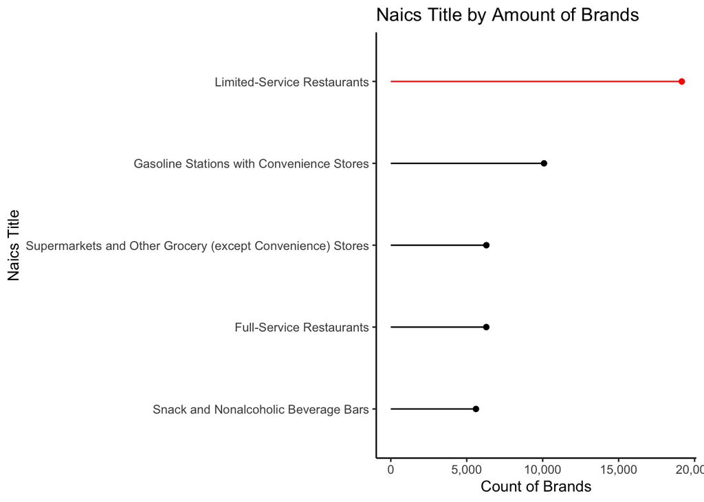

```r
brands = ov %>%
  filter(brands!='') %>%
  group_by(naics_title) %>%
  summarize(brand = n()) %>%
  arrange(-brand) %>%
  slice(1:5)

brands %>%
ggplot(mapping = aes(x=reorder(naics_title,brand),y=brand))+
  geom_segment(aes(xend = naics_title, yend = 0),color=ifelse(brands$naics_title=="Limited-Service Restaurants","red","black"), show.legend = FALSE) +
  geom_point(color=ifelse(brands$naics_title=="Limited-Service Restaurants","red","black"), show.legend = FALSE) +
  coord_flip()+
  labs(x="Naics Title", y = "Count of Brands", title = "Naics Title by Amount of Brands")+
  theme_classic()+
  scale_y_continuous(labels = comma)
```

## Chart 2 - Most Visited Brand for **Restaurants and Other Eating Places**

Taking a closer look at our data, I saw that Limited-Service Restaurants, Full-Service Resturants, and Snack and Nonalcoholic Beverage Bars part of the same beginning naics code, beginning in 7225, which represents “**Restaurants and Other Eating Places”.** From my understanding, these places range from cafe, fast food restaurants, to fine-dining. Thus, through this chart, I aimed to find a brand or store that has the most visits in this industry by finding its total visit in July of 2020. I came to the conclusion that the business that I will try to observe and improve will be Starbucks.

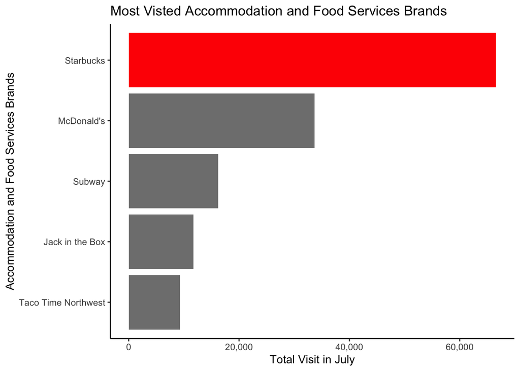

```r
FoodIndustry = dv %>%
  filter(brands!='') %>%
  group_by(brands) %>%
  mutate(naics_code_first_2=floor(naics_code/100))%>%
  filter(naics_code_first_2==7225) %>%
  group_by(brands) %>%
  summarise(total_visits = sum(visits_by_day,na.rm = TRUE)) %>%
  arrange(-total_visits) %>%
  slice(1:5)

## draw a chart
FoodIndustry %>%
ggplot(mapping = aes(x=reorder(brands,total_visits),y=total_visits,fill=(ifelse(brands=="Starbucks","highlighted","normal"))))+
  scale_fill_manual(name = "brands", values=c("red","grey50")) +
  geom_col(show.legend = FALSE)+
  coord_flip()+
  labs(x="Accommodation and Food Services Brands", y = "Total Visit in July", title = "Most Visted Accommodation and Food Services Brands")+
  theme_classic()+
  scale_y_continuous(labels = comma)
```

## Chart 3 - Daily Visits of Starbucks

I wanted to observe Starbucks’ daily foot traffic and see any trends. Through my chart, I was able to see that there is a cycle in which Starbucks’ visits follow. This information could be used to tremendously improve a business. For instance, Starbucks could increase advertisement on certain days to improve traffic or do sales promotion which could increase interests. Moreover, looking at costs, Starbucks could also reduce the number of employees on certain days, though this type of decision will need further studies.

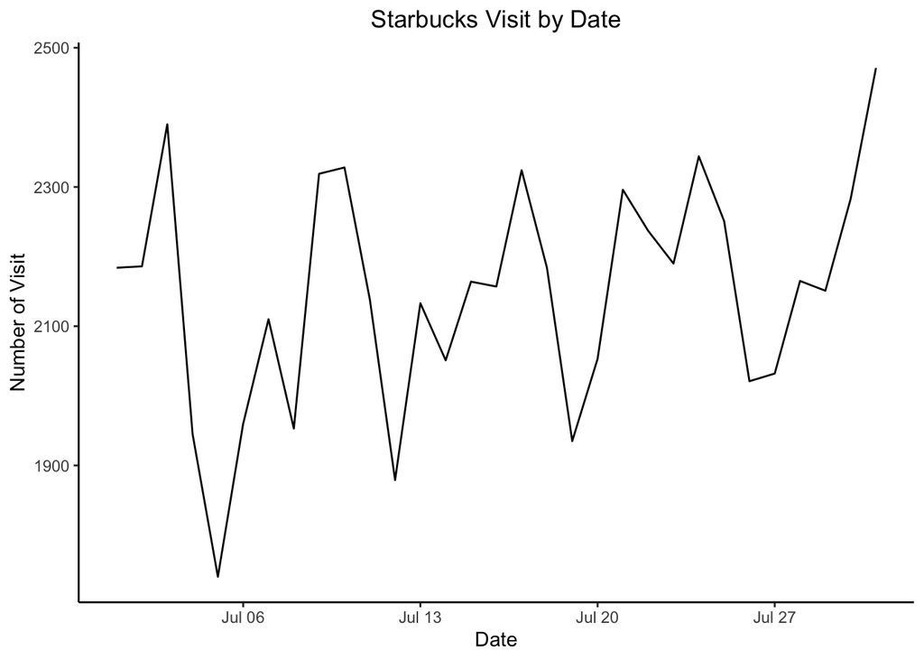

```r
starbucks = dv %>%
  filter(brands=="Starbucks")

starbucks %>%
  ggplot(aes(x=date,y=visits_by_day))+
  geom_line()+
  theme_classic()+
  labs(title = "Starbucks Visit by Date", x = "Date", y = "Number of Visit")+
  theme(plot.title = element_text(hjust = 0.5))
```

## Chart 4 - Average Visits to Starbucks based on Day of The Week

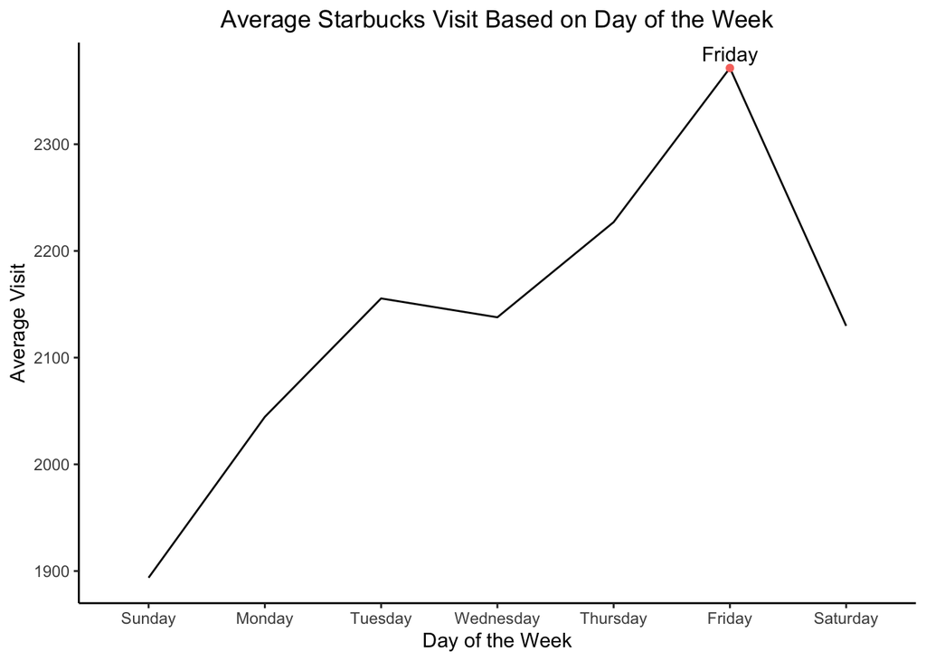

```r
starbucksday = dv %>%
  filter(brands=="Starbucks") %>%
  mutate(DayOfWeek = wday(ymd(date), label = TRUE, abbr = FALSE)) %>%
  group_by(DayOfWeek) %>%
  summarise(countOfVisits = mean(visits_by_day))

starbucksday %>%
  ggplot(aes(x=DayOfWeek,y=countOfVisits,group=1))+
  geom_line()+
  geom_text(aes(label=ifelse(countOfVisits == max(countOfVisits),"Friday","")),vjust=-0.5)+
  geom_point(data = starbucksday %>% filter(DayOfWeek == "Friday"), aes(color = "Red"),show.legend = FALSE)+
  theme_classic()+
  labs(title = "Average Starbucks Visit Based on Day of the Week", x = "Day of the Week", y = "Average Visit")+
  theme(plot.title = element_text(hjust = 0.5))
```

## Chart 5 - Creating a heat map of Starbucks’ Customers

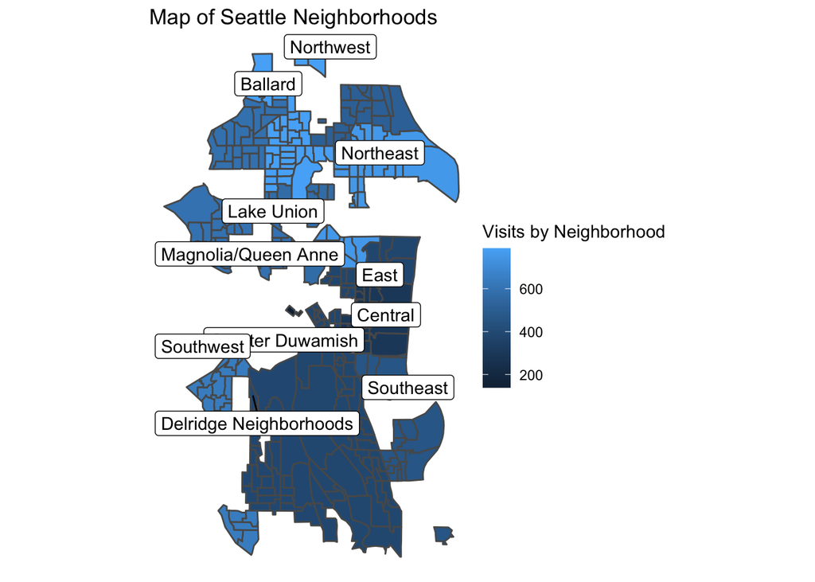

```r
ov2 <- ov %>%
  filter(brands=="Starbucks") %>%
  group_by(GEOID) %>%
  summarise(visits = sum(visits))
mapdata <- block_groups('WA','033', cb = TRUE, progress_bar = FALSE)
map_and_data <- geo_join(mapdata, ov, by = 'GEOID', how = 'left')
ov3 <- ov2 %>%
  right_join(neighborhood_names) %>%
  group_by(NEIGHBORHOOD_DISTRICT_NAME) %>%
  mutate(neighb_visits = sum(visits, na.rm = TRUE))
map_w_neighborhoods <- geo_join(mapdata, ov3, by = 'GEOID', how = 'inner')
neighbmap <- ov3 %>%
  # Only draw Seattle
  right_join(neighborhood_names) %>%
  # Only label each neighborhood once
  group_by(NEIGHBORHOOD_DISTRICT_NAME) %>%
  mutate(neighborhood_label =
           case_when(
             row_number() == 1 ~ NEIGHBORHOOD_DISTRICT_NAME,
             TRUE ~ NA_character_
           )) %>%
  ungroup()
neighbmap <- geo_join(mapdata, neighbmap, by = 'GEOID', how = 'inner')
ggplot(neighbmap) +
  geom_sf(aes(fill = neighb_visits)) +
  theme_void()+
  labs(title = 'Map of Seattle Neighborhoods') +
  geom_sf_label_repel(aes(label = neighborhood_label))+
  labs(fill="Visits by Neighborhood")
```